# Hertz pra todos

Na década de 1940, quando muitas residências já possuíam aparelhos de rádio, o engenheiro Arthur Lauro Xavier Moura percebeu um problema: mesmo tendo um rádio, algumas famílias não conseguiam utilizá-lo por não receberem sinal de transmissão.

Para resolver esse problema, o engenheiro criou o projeto *Hertz pra Todos*, cujo objetivo era ampliar a cobertura de rádio e permitir que mais residências recebessem sinal.

Para organizar o projeto, ele representou a região em um plano cartesiano, contendo $n$ residências e $m$ torres de transmissão já instaladas.

Cada residência está localizada em um ponto $(x_i,y_i)$. Cada torre de transmissão possui uma posição $(a_i,b_i)$ e um raio de cobertura $r_i$.

Uma residência recebe sinal de uma torre se ela estiver dentro da sua área de alcance.

Para ampliar a cobertura, o engenheiro decidiu instalar uma nova torre, denominada **Torre X**, cujo raio de cobertura é $R$.

A Torre X pode ser instalada em qualquer ponto $(x,y)$ com coordenadas inteiras, satisfazendo $0 \le x,y \le 1000$.

Sua tarefa é determinar a posição da Torre X que **maximize a quantidade total de residências atendidas**, considerando tanto as torres existentes quanto a nova torre.

Caso existam várias posições que proporcionem a mesma quantidade máxima de residências atendidas, escolha a posição com o menor valor de $x$. Em caso de empate, escolha aquela com o menor valor de $y$.

Se todas as residências já estiverem recebendo sinal das torres existentes, não será necessário instalar a Torre X.

## Entrada

A primeira linha contém três inteiros $n$, $m$ e $R$ ($1 \leq n \leq 10^4$, $1 \leq m \leq 10^3$, $1 \leq R \leq 1000$), representando, respectivamente, a quantidade de residências, a quantidade de torres existentes e o raio de cobertura da Torre X.

As próximas $n$ linhas contêm dois inteiros $x_i$ e $y_i$ ($0 \leq x_i, y_i \leq 1000$), representando as coordenadas de cada residência.

As próximas $m$ linhas contêm três inteiros $a_i$, $b_i$ e $r_i$ ($0 \leq a_i, b_i \leq 1000$, $1 \leq r_i \leq 1000$), representando as coordenadas e o raio de cobertura de cada torre existente.

## Saída

Caso todas as residências já possuam sinal, imprima um único inteiro $-1$.

Caso contrário, imprima três inteiros $q$, $x$ e $y$, em que $q$ representa a quantidade máxima de residências atendidas após a instalação da Torre X, e $(x,y)$ representa a posição escolhida.

## Notas

As residências $(0,0)$, $(1,0)$ e $(9,9)$ já recebem sinal das torres existentes. Instalando a Torre X em $(4,0)$ com $R=2$, as residências $(4,0)$, $(5,0)$ e $(4,2)$ ficam a distâncias $0$, $1$ e $2$ da nova torre, e todas as $6$ ficam atendidas. A posição $(4,1)$ também serviria, mas $(4,0)$ tem o menor $y$ entre as que têm o menor $x$ possível. A figura abaixo ilustra o exemplo dado:

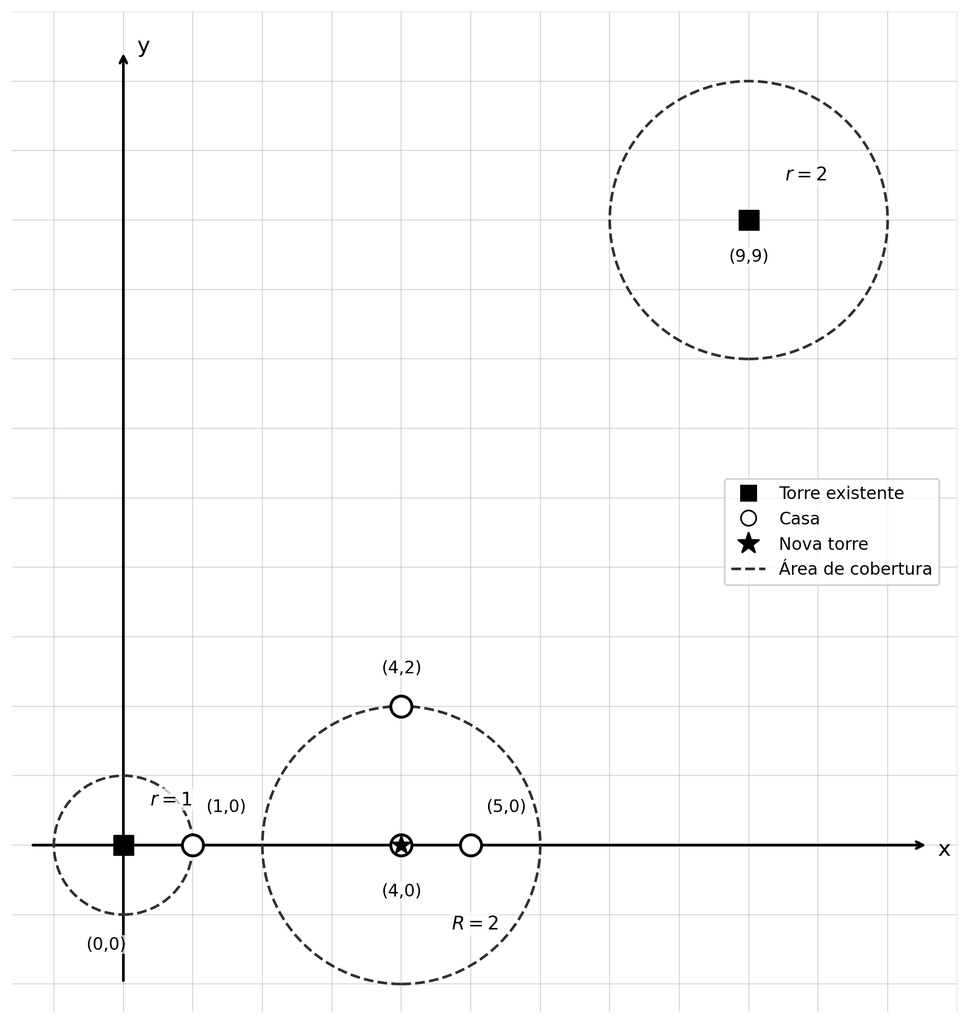

## Exemplos

### Entrada

```
6 2 2
0 0
1 0
4 0
5 0
4 2
9 9
0 0 1
9 9 2
```

### Saída

```
6 4 0
```